# Joint Gaussian Scale Optimization in terradish

Bill Peterman

## 1 Why optimize sigma inside the model?

The original `radish` workflow for raster smoothing usually worked in two steps:

1. Smooth each raster at several candidate scales.
2. Fit a resistance model to each smoothed raster surface and compare the fits.

That approach is still useful, but it treats scale as an **outer** tuning parameter. The new native Gaussian conductance system in `terradish` moves the scale parameter into the conductance model itself, so the optimizer can update:

- the conductance coefficient(s), and
- the smoothing scale(s)

in the same likelihood calculation.

This vignette shows the current implementation of that idea using `gaussian_smoothed_loglinear_conductance()`.

## 2 What sigma means here

For a raster covariate `x`, the Gaussian scale-aware model first smooths the raster with a Gaussian kernel and then uses the smoothed values in the usual log-linear conductance model.

Conceptually:

$$C_i = \exp(\theta \cdot
x_{i,\sigma})$$

where:

- $x_{i,\sigma}$ is the Gaussian-smoothed raster value at cell *i*, standardized over retained cells after smoothing
- $\theta$ is the conductance coefficient
- $\sigma$ controls how broad the smoothing kernel is

Small `sigma` means that the raster is averaged over a narrow neighborhood. Large `sigma` means that it is averaged over a broader neighborhood. The coefficient `theta` describes a one-standard-deviation change in that smoothed layer, with standardization recomputed at each trial scale. Its magnitude therefore needs to be interpreted jointly with `sigma`. Here, `sigma` is a Gaussian smoothing scale in the raster’s map units. It is not an estimate of dispersal distance, home-range size, movement distance, or the spatial scale of a causal ecological process. Dispersal can average exposure over a neighborhood, so a fitted positive scale may reflect that averaging even when the underlying ecological response is local.

### 2.1 Are there limits on sigma?

Yes. `terradish` now estimates `sigma` directly on its natural distance scale and fits it within explicit lower and upper bounds.

By default, those bounds are data-derived:

- the lower bound is half of the mean raster cell width
- the upper bound is `min(nrow(raster), ncol(raster)) * mean(res(raster)) / 6`, approximately one-sixth of the smaller raster dimension for square cells

You can override those defaults with `sigma_lower =` and `sigma_upper =` when you create the conductance model. The kernel is truncated to a raster-sized window. The default upper bound keeps approximately three standard deviations inside half the smaller dimension; larger requested bounds issue a truncation warning. Near that upper bound the covariate can become almost constant, so scale and effect size may be weakly identified. The half-cell lower bound still smooths and is not equivalent to an unsmoothed raster.

Internally, the optimizer now works on a converted sigma scale by default, using approximate cell-width units. The fitted coefficients and summaries are still reported back in map units for users, so the conversion helps the optimization without changing the interpretation target.

Two practical caveats are worth keeping in mind:

- factor-valued raster layers are rejected for this Gaussian conductance model rather than being treated as scalable predictors
- leverage / `partial_X` diagnostics are still unavailable, because the current diagnostic machinery assumes a one-to-one match between conductance parameters and design-matrix covariates

## 3 Worked example

We will fit a small staged example using the `melip` data. To keep the vignette fast and stable, we will:

- use only eight sampling sites
- start with one raster covariate (`forestcover`)
- use `mlpe` as the measurement model, because the response matrix contains non-independent pairwise genetic distances

This is enough to show the practical workflow without making the vignette slow. The main goal here is not to maximize model complexity. Instead, we will use the staged workflow that is usually safest for real data:

1. fit a one-raster Gaussian scale model
2. compare it to a standard fixed-raster model
3. only then add a second raster and inspect whether the fitted scales still behave sensibly

```r
library(terradish)
library(terra)

data(melip)
melip.forestcover <- terra::unwrap(melip.forestcover)
melip.altitude <- terra::unwrap(melip.altitude)
melip.coords <- terra::unwrap(melip.coords)

keep <- 1:8
melip.Fst <- melip.Fst[keep, keep, drop = FALSE]
coords <- melip.coords[keep]
```

### 3.1 Step 1: Build a conductance surface with the original raster

Unlike the standard fixed-raster workflow, we do not need to pre-scale the raster with `scale_covariates()` here. At each parameter evaluation, the Gaussian conductance model smooths the supplied raster and then standardizes its active-cell values. Pre-scaling applies a positive affine transformation, so it gives the same standardized smoothed values up to numerical tolerance. We retain the original units to make the preprocessing easier to follow.

```r
covariates <- melip.forestcover
names(covariates) <- "forestcover"

surface <- conductance_surface(
  covariates,
  coords,
  directions = 8,
  saveStack = TRUE
)
```

Two details matter here:

- `saveStack = TRUE` is required, because the Gaussian conductance model needs the retained raster stack as its smoothing domain.
- The fitted smoothing scale is in map units, regardless of whether the raster values were pre-scaled.

### 3.2 Step 2: Create the Gaussian scale-aware conductance model

```r
gaussian_model <- gaussian_smoothed_loglinear_conductance(surface)
```

This conductance model will estimate two parameters:

- `forestcover`: the conductance coefficient
- `sigma.forestcover`: the Gaussian smoothing scale on the natural distance scale

The same mechanism also supports interactions and polynomial terms after smoothing, but it is usually better to start with the simplest one-raster model you can justify.

### 3.3 Step 3: Fit the one-raster Gaussian scale model

`optimizer = "auto"` currently resolves to BFGS for this conductance model. That is intentional: the native Gaussian scale path supports analytic gradients, and BFGS is the stable first optimizer for the joint vector of conductance coefficients (`theta`) and smoothing scales (`sigma`).

```r
fit_gaussian <- terradish(
  melip.Fst ~ forestcover,
  data = surface,
  conductance_model = gaussian_model,
  measurement_model = mlpe,
  optimizer = "auto",
  leverage = FALSE,
  control = NewtonRaphsonControl(maxit = 100, verbose = FALSE)
)

fit_gaussian
```

```
#> Conductance surface estimated by maximum likelihood
#> Call:   terradish(formula = melip.Fst ~ forestcover, data = surface,
#>     conductance_model = gaussian_model, measurement_model = mlpe,
#>     leverage = FALSE, optimizer = "auto", control = NewtonRaphsonControl(maxit = 100,
#>         verbose = FALSE))
#>
#> Coefficients:
#>       forestcover  sigma.forestcover
#>          0.005437           0.062326
#>
#> Loglikelihood: 111.8816 (6 degrees freedom)   AIC: -211.7632
#> Convergence: converged | projected gradient: 4.31e-07
```

```r
fit_gaussian$convergence
```

```
#> $code
#> [1] 0
#>
#> $message
#> [1] "converged"
#>
#> $iterations
#> [1] 8
#>
#> $max_abs_projected_gradient
#> [1] 4.312654e-07
#>
#> $criterion
#> [1] "objective_and_projected_gradient"
#>
#> $boundary
#> [1] FALSE
#>
#> $restarted
#> [1] FALSE
```

### 3.4 Optional speed-up: coarse-raster warm starts

Gaussian scale optimization can be expensive because every likelihood evaluation has two costly pieces:

1. smooth the raster at the proposed `sigma`
2. solve the graph Laplacian to get resistance distances

For large rasters, you can ask `terradish()` to optimize first on one or more aggregated rasters and then refine the result on the original surface:

```r
fit_gaussian_coarse <- terradish(
  melip.Fst ~ forestcover,
  data = surface,
  conductance_model = gaussian_model,
  measurement_model = mlpe,
  approximation = "coarse_raster",
  approximation_control = list(
    factor = c(4, 2),
    exact_refine = TRUE
  ),
  optimizer = "auto",
  leverage = FALSE,
  control = NewtonRaphsonControl(maxit = 100, verbose = FALSE)
)
```

The coarse stages rebuild the Gaussian smoother on each aggregated raster, but they keep the full-resolution `sigma` bounds and unit conversion. That means a coarse-stage `sigma` is still interpreted in the original map units. With `exact_refine = TRUE`, the final model is not a coarse approximation; it is the full-resolution fit initialized from the coarse result.

### 3.5 Step 4: Inspect the fitted one-raster scale

```r
coef(fit_gaussian)
```

```
#>       forestcover sigma.forestcover
#>       0.005436958       0.062326149
```

```r
summary(fit_gaussian)$sigma_table
```

```
#>         layer   estimate        SE lower_bound upper_bound near_bound
#> 1 forestcover 0.06232615 0.7643893      0.0225        1.17      FALSE
```

```r
confint(fit_gaussian)
```

```
#>                       2.5 %    97.5 %
#> forestcover       -0.262495 0.2733689
#> sigma.forestcover  0.022500 1.1700000
#> attr(,"note")
#> [1] "Gaussian scale Wald intervals are truncated at the fitted bounds."
```

The conductance coefficient tells us whether smoothed forest cover is associated with higher or lower conductance. The scale parameter is already on its natural scale, so we can summarize it directly:

```r
coef(fit_gaussian)[["sigma.forestcover"]]
```

```
#> [1] 0.06232615
```

**How to read the output.** The scale table includes its estimate, standard error, and proximity to a fitting bound. Wald intervals from `confint()` are limited to those bounds; a bound-limited interval does not establish an interior optimum. Inspect the likelihood profile when scale is important:

```r
# Refit the other parameters at a grid of fixed forest-cover scales.
profile <- gaussian_scale_profile(fit_gaussian, "forestcover", n = 15)
profile$interval
confint(profile$fit)
```

The returned fit stores the profile interval. Increase grid resolution when the profile is irregular. Failed profile fits stop the calculation rather than being silently omitted. Boundary likelihood-ratio calibration remains approximate; report a bound-limited interval as such.

`gaussian_scale_summary()` converts the fitted sigma values into:

- the native raster distance scale
- the internal optimization scale and its conversion factor
- raster cell widths
- one-dimensional Gaussian half-widths
- two-dimensional radial extents that contain a chosen amount of kernel mass

```r
gaussian_scale_summary(fit_gaussian)
```

```
#>     covariate      sigma sigma_lower sigma_upper sigma_internal
#> 1 forestcover 0.06232615      0.0225        1.17       1.385026
#>   sigma_conversion sigma_conversion_mode native_unit sigma_cells_x
#> 1            0.045                  cell     degrees      1.385026
#>   sigma_cells_y    axis_50  radial_50  axis_95 radial_95
#> 1      1.385026 0.04203835 0.07338343 0.122157 0.1525586
```

That table is often the quickest way to interpret the fitted smoothing scale. For example, `radial_95` is the radius that contains approximately 95% of the untruncated Gaussian kernel mass, while `sigma_cells_x` and `sigma_cells_y` show how broad the smoothing kernel is relative to the raster resolution. These ideal Gaussian radii are descriptive; raster truncation and edge handling can change the realized weights.

You can also visualize the fitted kernel directly. The `sigma` plot shows the Gaussian weight curve over distance for each fitted scale parameter, with a vertical dashed line at the fitted distance containing 90% of the one-dimensional kernel mass and a shaded uncertainty band for that distance. Each panel is also annotated with:

- the fitted `sigma`
- the fitted 90% kernel-mass distance
- the corresponding confidence interval bounds

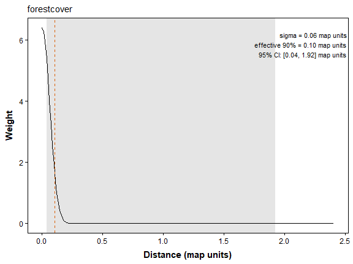

*Fitted Gaussian kernel with uncertainty band. The dashed line marks the distance containing 90% of the one-dimensional kernel mass.*

```r
plot(fit_gaussian, type = "sigma")
```

If you already know how to convert your map units into a more interpretable distance scale, you can relabel the plot directly. For example, if one map unit corresponds to one meter, then multiplying by `0.001` reports distances in kilometers. This conversion is only valid for a meter-based raster; do not apply it to longitude/latitude degrees:

```r
plot(
  fit_gaussian,
  type = "sigma",
  distance_per_map_unit = 0.001,
  distance_unit = "km"
)
```

### 3.6 Step 5: Compare against a standard fixed-raster fit

The scale-aware fit is easiest to interpret when it is compared directly to the same model without an estimated `sigma`.

```r
fit_fixed <- terradish(
  melip.Fst ~ forestcover,
  data = surface,
  conductance_model = loglinear_conductance,
  measurement_model = mlpe,
  optimizer = "auto",
  leverage = FALSE,
  control = NewtonRaphsonControl(maxit = 100, verbose = FALSE)
)

fit_fixed
```

```
#> Conductance surface estimated by maximum likelihood
#> Call:   terradish(formula = melip.Fst ~ forestcover, data = surface,
#>     conductance_model = loglinear_conductance, measurement_model = mlpe,
#>     leverage = FALSE, optimizer = "auto", control = NewtonRaphsonControl(maxit = 100,
#>         verbose = FALSE))
#>
#> Coefficients:
#> forestcover
#>     0.05858
#>
#> Loglikelihood: 111.8835 (5 degrees freedom)   AIC: -213.767
#> Convergence: converged | projected gradient: 1.15e-13
```

```r
aic_table(
  list(fit_gaussian, fit_fixed),
  mod_names = c("Gaussian scale-aware", "Fixed raster")
)
```

```
#>                  model K       AIC Delta_AIC AIC_wt Cum.wt   loglik converged
#> 2         Fixed raster 5 -213.7670    0.0000 0.7314 0.7314 111.8835      TRUE
#> 1 Gaussian scale-aware 6 -211.7632    2.0038 0.2686 1.0000 111.8816      TRUE
#>   boundary
#> 2    FALSE
#> 1    FALSE
```

The two fits use the same response, sites, graph, and MLPE likelihood, so their AIC values have a common basis. The scale-aware model’s parameter count includes the estimated smoothing scale. In a larger analysis, declare the candidate scale and formula set before comparing it, and report the search that was performed.

Assess whether the scale is identified away from its bounds, whether the profile supports a useful range, and whether estimating it improves held-out prediction. With only eight sites this illustration cannot provide a strong spatial-transfer assessment. On a larger sampling design, use common folds and a distinct conductance factory for each candidate:

```r
# Center a local distance projection on the sampled Brazilian sites.
lonlat <- terra::crds(terra::project(coords, "EPSG:4326"))
local_crs <- sprintf("+proj=aeqd +lat_0=%f +lon_0=%f +datum=WGS84 +units=m",
                     mean(lonlat[, 2]), mean(lonlat[, 1]))
coords_projected <- terra::project(coords, local_crs)
folds <- terradish_folds(coords_projected, k = 2, seed = 42)
cv_scale <- terradish_cv_folds(
  data = surface,
  formulas = list(fixed = melip.Fst ~ forestcover,
                  gaussian = melip.Fst ~ forestcover),
  folds = folds, model = mlpe, nuisance = "fixed",
  conductance_model = list(fixed = loglinear_conductance,
                           gaussian = gaussian_model),
  control = NewtonRaphsonControl(maxit = 100)
)
cv_scale$summary
```

Inspect failures and paired differences on common successful folds. A scale that improves in-sample fit but not prediction needs cautious interpretation.

### 3.7 Step 6: Summarize the one-raster fit

```r
summary(fit_gaussian)
```

```
#> Conductance surface with 22443 vertices (8 focal) estimated by maximum likelihood
#> Call:   terradish(formula = melip.Fst ~ forestcover, data = surface,
#>     conductance_model = gaussian_model, measurement_model = mlpe,
#>     leverage = FALSE, optimizer = "auto", control = NewtonRaphsonControl(maxit = 100,
#>         verbose = FALSE))
#>
#> Loglikelihood: 111.8816 (6 degrees freedom)
#> AIC: -211.7632
#>
#> Number of function calls: 36
#> Number of optimization steps: 8
#> Convergence: converged | projected gradient: 4.31e-07
#> Norm of gradient at MLE: 4.312673e-07
#>
#> Gaussian scales (map units; no Wald test against zero):
#>        layer   estimate        SE lower_bound upper_bound near_bound
#>  forestcover 0.06232615 0.7643893      0.0225        1.17      FALSE
#> near_bound marks estimates within 1% of a bound.
#>
#> Nuisance parameters (conditional on fitted conductance surface; measurement-model scale):
#>        Estimate   Std. Error  Lower 95%  Upper 95%
#> alpha  -0.025779   0.009775   -0.044938  -0.006619
#> beta    0.249115   0.018816    0.212236   0.285993
#> tau     8.312354   0.419069    7.490994   9.133714
#> rho     1.055388   0.667221   -0.252341   2.363117
#>
#> Coefficients:
#>                   Estimate Std. Error z value Pr(>|z|)
#> forestcover       0.005437   0.136702    0.04    0.968
#> sigma.forestcover 0.062326   0.764389      NA       NA
#>
#> Correlation of Coefficients:
#>                   forestcover
#> sigma.forestcover  0.01533939
```

For this conductance model, the coefficient table includes both:

- the conductance coefficient, and
- `sigma`

So the scale parameter is treated just like any other model parameter in the joint optimization.

### 3.8 Step 7: Recover the fitted conductance surface

Once the model is fitted, the usual conductance helper still works.

```r
fitted_conductance <- conductance(surface, fit_gaussian)
fitted_conductance
```

```
#> class       : SpatRaster
#> size        : 156, 180, 3  (nrow, ncol, nlyr)
#> resolution  : 0.045, 0.045  (x, y)
#> extent      : -42.9125, -34.8125, -9.4975, -2.4775  (xmin, xmax, ymin, ymax)
#> coord. ref. : +proj=longlat +ellps=WGS84 +towgs84=0,0,0,0,0,0,0 +no_defs
#> source(s)   : memory
#> names       :      est,  lower95,  upper95
#> min values  : 0.994312, 0.311683, 1.001337
#> max values  : 1.024431, 0.998718, 3.367077
```

And we can plot the fitted conductance layer directly:

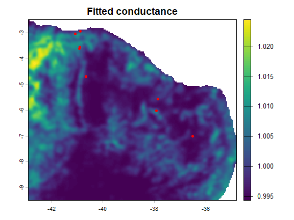

*Fitted conductance surface from the Gaussian scale-aware model, with sampling sites shown in red.*

```r
plot(fitted_conductance[[1]], main = "Fitted conductance")
points(coords, pch = 19, col = "red")
```

When tails are weakly supported at focal sites, you can request focal-support clamping directly in prediction:

```r
fitted_conductance_focal <- conductance(
  surface,
  fit_gaussian,
  support = "focal",
  support_probs = c(0.01, 0.99),
  clamp_covariates = "forestcover"
)
```

## 4 Stage 2: Add a second raster only after sigma looks sensible

Once the one-raster scale parameter looks stable enough to trust, we can add a second raster and inspect whether the scale estimates remain interpretable.

```r
covariates_two <- c(melip.altitude, melip.forestcover)
names(covariates_two) <- c("altitude", "forestcover")

surface_two <- conductance_surface(
  covariates_two,
  coords,
  directions = 8,
  saveStack = TRUE
)
```

```r
fit_gaussian_two <- terradish(
  melip.Fst ~ forestcover + altitude,
  data = surface_two,
  conductance_model = gaussian_smoothed_loglinear_conductance(surface_two),
  measurement_model = mlpe,
  optimizer = "auto",
  leverage = FALSE,
  control = NewtonRaphsonControl(maxit = 100, verbose = FALSE)
)

fit_gaussian_two
```

```
#> Conductance surface estimated by maximum likelihood
#> Call:   terradish(formula = melip.Fst ~ forestcover + altitude, data = surface_two,
#>     conductance_model = gaussian_smoothed_loglinear_conductance(surface_two),
#>     measurement_model = mlpe, leverage = FALSE, optimizer = "auto",
#>     control = NewtonRaphsonControl(maxit = 100, verbose = FALSE))
#>
#> Coefficients:
#>       forestcover           altitude  sigma.forestcover     sigma.altitude
#>          -0.19478           -0.32984            0.03088            0.02250
#>
#> Loglikelihood: 115.5793 (8 degrees freedom)   AIC: -215.1586
#> Convergence: converged | projected gradient: 1.07e-05
```

```r
gaussian_scale_summary(fit_gaussian_two)
```

```
#>     covariate      sigma sigma_lower sigma_upper sigma_internal
#> 1 forestcover 0.03088079      0.0225        1.17      0.6862397
#> 2    altitude 0.02250000      0.0225        1.17      0.5000000
#>   sigma_conversion sigma_conversion_mode native_unit sigma_cells_x
#> 1            0.045                  cell     degrees     0.6862397
#> 2            0.045                  cell     degrees     0.5000000
#>   sigma_cells_y    axis_50  radial_50    axis_95  radial_95
#> 1     0.6862397 0.02082877 0.03635935 0.06052523 0.07558835
#> 2     0.5000000 0.01517602 0.02649173 0.04409919 0.05507430
```

This is exactly the point where the staged workflow helps. If one or more sigma estimates now collapse to the lower bound, or drift toward the upper bound, that is useful information. It suggests one of several things:

- the added raster may not need smoothing at all
- the data may not support estimating multiple scales simultaneously
- the smaller one-raster scale was not as stable as it first appeared

Check convergence separately from boundary status. A converged boundary fit can indicate limited scale information or preference for an extreme allowed scale. A nonconverged fit requires numerical investigation before ecological interpretation.

In the small `melip` subset used here, that is exactly the kind of pattern to watch for: the one-raster `forestcover` scale can be inspected on its own before adding `altitude`. After `altitude` is added, one or both fitted scale parameters may move toward the lower bound, which is a cue to proceed cautiously rather than immediately adding more landscape terms.

## 5 Outer scale searches

`terradish_scale_optim()` remains available for an outer search, while joint Gaussian fitting provides derivatives and joint scale inference directly. Outer-search radii are in map units and the default outer kernel is Gaussian. A Gaussian standard deviation, a uniform-disk radius, and other kernel parameters represent different weighting functions even when their numeric values match. Record the kernel, units, search bounds, and estimated scales. The parameter count includes optimized scales; repeated searching is still part of the declared model-selection procedure. Prefer projected rasters when distances are to be interpreted in meters or kilometers.

## 6 Important current limitations

This first version is intentionally focused. Right now it supports:

- additive formulas made of raw numeric raster names
- interactions among numeric raster names
- polynomial/arithmetic terms such as `I(forestcover^2)`
- one Gaussian scale parameter per selected raster
- joint optimization through analytic gradients and BFGS
- opt-in coarse-raster starts through `approximation = "coarse_raster"`

It does **not yet** support:

- factor-valued raster layers
- leverage / `partial_X` diagnostics

It does now support conditional-on-sigma marginal-association plotting, so you can inspect conductance and response-scale curves after fitting, but the leverage machinery is still intentionally disabled.

## 7 Where to go with your analysis

If this workflow looks reasonable for your data, practical steps are:

1. Fit a small one-raster model first and inspect `sigma`.
2. Compare it to a standard fixed-raster `loglinear_conductance` fit.
3. Add additional rasters only after the one-raster scale parameter behaves sensibly.
4. Treat boundary-hitting sigma estimates as a model-selection signal, not just an optimization nuisance.
5. Reproject rasters before interpreting smoothing distances, because longitude/latitude rasters report sigma in degrees.

This staged approach makes it easier to assess whether the likelihood identifies an interior Gaussian smoothing scale under the fitted model. An identified smoothing scale is not, by itself, an identified movement or ecological-process scale.

## 8 Quick reference: the full scale-optimization workflow

```r
library(terradish)

# 1. Build the surface from the ORIGINAL raster; do not pre-smooth it
surface <- conductance_surface(covariates, coords, directions = 8,
                               saveStack = TRUE)

# 2. Scale-aware conductance model: sigma is estimated, not fixed. The model
#    is built from the surface itself; sigma_upper bounds the search in map
#    units, and defaults to the smaller raster dimension / 6 for square cells.
cm <- gaussian_smoothed_loglinear_conductance(surface)

# 3. Fit; theta and sigma.<layer> are estimated jointly
fit <- terradish(melip.Fst ~ forestcover, data = surface,
                 conductance_model = cm, measurement_model = mlpe)

# 4. Read the fitted scale. `sigma` is in map units, so reproject a
#    longitude/latitude raster first or it will be reported in degrees.
gaussian_scale_summary(fit)   # sigma + kernel-mass distances in map units

# 5. Sanity check against a fixed-raster fit of the same covariate
fit_fixed <- terradish(melip.Fst ~ forestcover, data = surface,
                       conductance_model = loglinear_conductance,
                       measurement_model = mlpe)
aic_table(list(fit, fit_fixed),
          mod_names = c("Scale-aware", "Fixed raster"))

# 6. Recover the conductance surface at the estimated scale
plot(conductance(surface, fit))
```

## 9 Summary of key functions

| Function | Purpose |
| --- | --- |
| `conductance_surface()` | Build the graph from the original, unsmoothed raster |
| `gaussian_smoothed_loglinear_conductance()` | Conductance model that estimates sigma jointly with theta |
| `terradish()` | Fit the scale-aware model |
| `gaussian_scale_summary()` | Fitted sigma per layer and corresponding Gaussian kernel-mass distances |
| `gaussian_scale_profile()` | Profile scale uncertainty while reoptimizing other parameters |
| `terradish_cv_folds()` | Compare fixed and estimated scales on common held-out sites |
| `conductance()` | Extract the fitted conductance surface at the estimated scale |
| `aic_table()` | Compare the scale-aware fit against a fixed-raster fit |

## 10 See also

- **`vignette("getting-started", package = "terradish")`**: the core `terradish` workflow: scaling covariates, building a conductance surface, fitting and interpreting models, and the five plot types.
- **`vignette("model-comparison", package = "terradish")`**: likelihood ratio tests, AIC/AICc/BIC tables, likelihood surface visualization, and cross-validation.
- **`vignette("ibe-ibr-workflow", package = "terradish")`**: fitting isolation by environment (IBE) and isolation by resistance (IBR) simultaneously in the same model.
- **`vignette("spline-conductance", package = "terradish")`**: fitting non-linear conductance responses with spline terms when the response shape is flexible but the raster scale is fixed.
- **`vignette("wishart-covariance", package = "terradish")`**: fitting covariance-based Wishart IBR models when raw genotype data are available.